# RMarkdown and knitr

Marc Los Huertos

EA030 · Compiled 2026-04-09

EA030 — Core R Skills — Module 02

# RMarkdown & knitr

**Prof. Marc Los Huertos** • Pomona College

← Back to R Tricks

What is Rmd? Anatomy YAML Header Markdown Prose Code Chunks Chunk Options Inline R The Setup Chunk Images Citations Rendering Troubleshooting

> **What this module covers.** An R Markdown file (`.Rmd`) weaves prose, code, and output into a single reproducible document. When you click **Knit**, knitr runs every chunk, captures its output, and pandoc converts everything to HTML, PDF, or Word. This module walks through every part of an Rmd file from scratch — YAML headers, markdown syntax, chunk options, inline R, and the rendering pipeline — so you understand not just *what* to write but *why* it works.

## 1. What Is R Markdown?

A plain `.R` script runs code and prints results to the Console. A `.Rmd` file does the same thing, but also lets you write formatted prose *around* that code — headings, paragraphs, bullet lists, equations — and produce a polished output document that a reader who has never opened RStudio can read.

The three technologies involved are:

| Layer | Tool | Role |
| --- | --- | --- |
| Text markup | **Markdown** | Headings, bold, lists, links, equations |
| Code execution | **knitr** | Runs R chunks, captures output and plots |
| Document conversion | **pandoc** | Converts the combined result to HTML/PDF/Word |

You never call pandoc or knitr directly. Clicking **Knit** (or running `rmarkdown::render()`) triggers all three in sequence.

**💡 Create your first Rmd now** In RStudio: **File → New File → R Markdown…**. Choose HTML output. RStudio generates a template with all three sections already present — read it, then delete everything below the setup chunk and start fresh.

## 2. The Anatomy of an Rmd File

Every Rmd file has exactly three kinds of content, always in this order at the top:

YAML Header

--- title: “My Report” author: “Marc Los Huertos” output: html_document ---

Setup Chunk

`{r setup, include=FALSE} knitr::opts_chunk$set(echo = TRUE, warning = FALSE)`

Code Chunk

`{r my-analysis} x <- c(1, 4, 9, 16, 25) mean(x)`

Prose

## Results

The mean value was 11. We collected data at **five** sites.

These three elements — YAML, chunks, and prose — can appear in any order after the header, interleaved as many times as needed. The YAML block must be the very first thing in the file.

## 3. The YAML Header

The YAML header controls the document’s metadata and output format. It is delimited by triple-dashes (`---`) and must appear at the very top of the file, before any other content.

### Minimal header

```
---
title: "Air Quality Analysis"
author: "Marc Los Huertos"
date: "2024-03-15"
output: html_document
---
```

### Dynamic date

Hard-coding the date means it goes stale. Use inline R instead so the date updates every time you knit:

```
date: "Compiled `r format(Sys.Date(), '%Y-%m-%d')`"
```

### Output formats

The `output:` field determines what pandoc produces. The most common options:

| output value | Produces | Requires |
| --- | --- | --- |
| `html_document` | Self-contained HTML file | nothing extra |
| `pdf_document` | PDF via LaTeX | a LaTeX installation (TinyTeX) |
| `word_document` | `.docx` Word file | nothing extra |
| `github_document` | Markdown for GitHub | nothing extra |

### HTML document options

```
output:
  html_document:
    toc: true              # table of contents
    toc_float: true        # floating sidebar TOC
    toc_depth: 3           # include h1, h2, h3 headings
    number_sections: true  # auto-number headings
    theme: flatly          # Bootswatch CSS theme
    highlight: tango       # syntax highlighting style
    self_contained: true   # embed all CSS/JS — one portable file
    df_print: paged        # paginated data frames
    code_folding: hide     # show "Code" buttons, hide by default
```

**⚠️ YAML is whitespace-sensitive** Indentation in YAML is *exactly two spaces* — not tabs, not four spaces. A misaligned line causes a cryptic parse error and the document will not knit. If you see `Error in yaml::yaml.load()`, the problem is almost always indentation or a missing colon.

### The custom `knit:` function

The modules in this course use a custom `knit:` field to redirect the output HTML to a specific folder. This is what lets the knit button send the file directly to the `docs/` folder without any manual copying:

```
knit: (function(inputFile, encoding) {
    rmarkdown::render(
      inputFile,
      encoding = encoding,
      output_file = file.path(dirname(inputFile),
                              "../docs/RGuides/02_RMarkdown_knitr.html")
    )
  })
```

Without this, clicking Knit places the HTML in the same folder as the Rmd. The `file.path(dirname(inputFile), "../docs/...")` pattern navigates relative to the Rmd’s location — so the path works on any machine regardless of the absolute path to the project.

**📁 dirname() and relative paths** `dirname(inputFile)` returns the folder the Rmd lives in. `“../docs/RGuides/…”` then navigates one level up (`..`) and into `docs/RGuides/`. This means the Rmd and the docs folder must be siblings — both children of the same project root — for the path to resolve correctly.

## 4. Markdown Prose

Between and around chunks, you write plain text with lightweight **markdown** formatting. Pandoc converts this to HTML or whatever output format you chose.

### Headings

```markdown
# Level 1 heading   (one #)
## Level 2 heading  (two ##)
### Level 3 heading (three ###)
```

Headings also create anchor links. Adding `{#my-id}` after the heading text lets you link to it:

```markdown
## Results {#results}

See the [Results section](#results) for details.
```

### Emphasis, lists, and links

```markdown
**bold text**
*italic text*
`inline code` — use for function names, variable names, file paths

- unordered list item
- another item
  - nested item (two spaces of indent)

1. ordered list item
2. second item

[link text](https://example.com)
```

### Block quotes and horizontal rules

```markdown
> A blockquote — useful for key questions or callouts.

&#45;&#45;&#45;    (three dashes = horizontal rule)
```

### Tables

```markdown
| Column A | Column B | Column C |
|----------|----------|----------|
| value 1  | value 2  | value 3  |
| value 4  | value 5  | value 6  |
```

The colons in the separator row control alignment:

```markdown
| Left     | Center   | Right    |
|:---------|:--------:|---------:|
| text     | text     | text     |
```

**💡 For data frames, use knitr::kable() instead** Never type a markdown table by hand for data. Use `knitr::kable(df)` or `kableExtra` — it generates the table automatically from your data so it updates when the data changes.

### Equations

R Markdown supports LaTeX math using `$` for inline and `$$` for display:

```markdown
The mean is $\bar{x} = \frac{1}{n} \sum_{i=1}^{n} x_i$.

$$
\text{PM}_{2.5} = \beta_0 + \beta_1 T + \varepsilon
$$
```

Renders as:

The mean is $\bar{x} = \frac{1}{n} \sum_{i=1}^{n} x_i$.

## 5. Code Chunks

A code chunk is a fenced block that knitr executes. The output — printed values, tables, plots — is inserted into the document immediately below the chunk.

### Chunk anatomy

Every chunk has the same structure:

````
```{r chunk-label, option1 = value, option2 = value}
# your R code here
x <- 1 + 1
x
```
````

- The opening fence is **exactly** `` ```{r `` — three backticks, open brace, the letter `r`, a space, then the label.
- The **label** is optional but strongly recommended. It appears in error messages and the knitr progress log, making debugging far easier.
- Labels must be **unique** across the entire document — duplicate labels cause an error at knit time.
- The closing fence is **exactly** `` ``` `` — three backticks, nothing else.

### Inserting a chunk

Three ways:

1. **Keyboard shortcut**: `Ctrl+Alt+I` (Windows/Linux) or `Cmd+Option+I` (Mac)
2. **Toolbar**: the green **Insert** button → R
3. **Typing**: type the backtick fence manually

### What gets printed

Whatever R would print to the Console also appears in the document:

```r
# Expressions that print their result automatically
42
```

```
## [1] 42
```

```r
c(1, 2, 3)
```

```
## [1] 1 2 3
```

```r
summary(c(2.1, 3.4, 2.8, 4.1, 3.9))
```

```
##    Min. 1st Qu.  Median    Mean 3rd Qu.    Max.
##    2.10    2.80    3.40    3.26    3.90    4.10
```

Assignments do **not** print unless you explicitly print the object or wrap in parentheses:

```r
x <- 10      # silent — nothing appears below this line
x            # now it prints
```

```
## [1] 10
```

```r
(y <- 20)    # wrapping assignment in () also prints
```

```
## [1] 20
```

### Plots are output too

Any plot created inside a chunk is captured and embedded in the document:

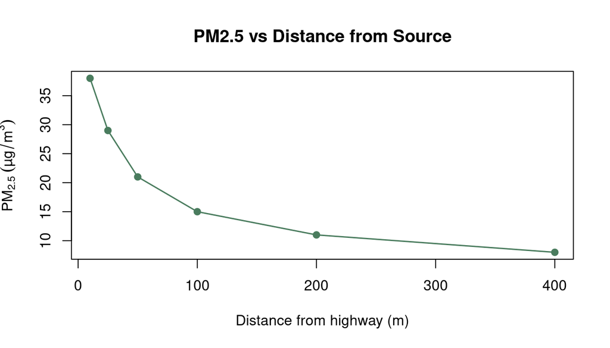

Particulate matter decreases with distance from the highway.

```r
distance_m  <- c(10, 25, 50, 100, 200, 400)
pm25_ug_m3  <- c(38, 29, 21, 15,  11,   8)

plot(distance_m, pm25_ug_m3,
     xlab = "Distance from highway (m)",
     ylab = expression(PM[2.5] ~ (µg/m^3)),
     pch  = 19, col = "#4a7c5e",
     main = "PM2.5 vs Distance from Source")
lines(distance_m, pm25_ug_m3, col = "#4a7c5e", lwd = 1.5)
```

## 6. Chunk Options

Chunk options control what knitr does with each chunk: whether to show the code, whether to run it, how large to make the figure. They go inside the `{r label, ...}` header, separated by commas.

### The essential options

echo

TRUE / FALSE

Show the source code in the output? `FALSE` hides code but still runs it and shows output.

eval

TRUE / FALSE

Run the chunk? `FALSE` shows code as a formatted block but does not execute it.

include

TRUE / FALSE

Include anything in the output? `FALSE` runs the chunk silently — code and output both hidden. Use for setup chunks.

message

TRUE / FALSE

Show `message()` output? Set `FALSE` to suppress library loading messages.

warning

TRUE / FALSE

Show warnings? Set `FALSE` to suppress, but check warnings interactively first — never hide problems you haven’t understood.

error

TRUE / FALSE

Default `FALSE` means an error *stops the knit*. Set `TRUE` to show the error in the output and continue knitting — useful in teaching documents.

fig.width

number (inches)

Width of the output figure in inches. Default 7. Combine with `fig.height` to control aspect ratio.

fig.height

number (inches)

Height of the output figure in inches. Default 5.

fig.cap

character string

Figure caption. Appears below the plot. Supports inline R for dynamic captions.

out.width

“100%”, “70%”, “400px”

Width of the figure in the HTML output. Use `“100%”` to fill the column, or a percentage to shrink it.

cache

TRUE / FALSE

Save chunk results and skip re-running if code hasn’t changed. Useful for slow model fits. Use with care — can cause stale results.

results

‘markup’, ‘hide’, ‘asis’, ‘hold’

`‘hide’` suppresses printed output. `‘asis’` passes raw HTML/LaTeX through (for kable). `‘hold’` collects all output and prints at the end of the chunk.

### Common combinations

Rather than listing chunk headers in a code block (which knitr would try to parse), here is a reference table of the most useful combinations:

| Goal | Options to set |
| --- | --- |
| Show code and output (default) | nothing — this is the default |
| Show output only, hide code | `echo = FALSE` |
| Show code only, don’t run | `eval = FALSE` |
| Run silently, show nothing | `include = FALSE` |
| Show plot only, hide code and messages | `echo = FALSE, message = FALSE` |
| Show error in output without stopping knit | `error = TRUE` |
| Show figure with caption at a specific size | `fig.cap = "...", fig.width = 6, fig.height = 4` |

Each option goes inside the chunk header after the label, separated by commas:

````r
# Example: a results table — output only, no code shown
# ```{r results-table, echo=FALSE}

# Example: install instructions — show code but never run
# ```{r install-packages, eval=FALSE}

# Example: setup — run silently, nothing in output
# ```{r setup, include=FALSE}
````

### Seeing options in action

The next three chunks are identical code but with different options — compare what appears in the rendered output:

```r
# echo=TRUE (default) — you see this code AND the output below
sqrt(144)
```

```
## [1] 12
```

```
## [1] 13
```

```r
# results='hide' — code appears, output is suppressed
sqrt(196)
```

### `fig.show` — controlling multi-plot chunks

When a chunk produces more than one plot, `fig.show` controls whether they share a figure environment or each get their own:

[output not shown]

[figure not shown]

[figure not shown]

`{r figcap-vector-demo, fig.show='hold', fig.width=3.5, fig.height=3, fig.cap=c("PM2.5 — roughly normal.", "PM10 — right-skewed.")} set.seed(1) hist(rnorm(300, mean = 12, sd = 4), main = "PM2.5", xlab = "µg/m³", col = "#4a7c5e", border = NA) hist(rexp(300, rate = 0.08), main = "PM10", xlab = "µg/m³", col = "#c8832a", border = NA)`

### `ref.label` — reusing a chunk without repeating code

`ref.label` runs a previous chunk again without copying its code. This is useful when you want to show code in one place and output in another, or produce the same plot at two different sizes:

[output not shown]

### `results = 'asis'` — passing raw HTML to the output

The default `results = 'markup'` wraps printed output in a code block. `results = 'asis'` passes the output directly into the document as raw HTML or markdown — required any time you generate tables or headings programmatically:

```r
# knitr::kable() generates an HTML table — needs results='asis' to render
# Without it, you'd see raw HTML tags as plain text
knitr::kable(
  data.frame(
    Site    = c("Kern", "Mojave", "Coast"),
    PM2.5   = c(12.1, 8.4, 18.0),
    n       = c(5L, 4L, 6L)
  ),
  caption = "Summary table generated inside a chunk."
)
```

Summary table generated inside a chunk.

| Site | PM2.5 | n |
| --- | --- | --- |
| Kern | 12.1 | 5 |
| Mojave | 8.4 | 4 |
| Coast | 18.0 | 6 |

**⚠️ kable() inside a for loop requires results=‘asis’** If you loop over groups and call `knitr::kable()` inside the loop, you *must* set `results=‘asis’` on that chunk or the tables will appear as raw HTML text. The same applies to any function that emits raw HTML — `kableExtra`, `gt`, `DT::datatable()`.